# Rainfall data for the Makay protected area, Madagascar

Source accessibility, station coverage and gridded rainfall over the Makay, November 2019 to October 2020

Published

November 16, 2026

## Purpose

This document assesses rainfall data sources for the Makay protected area in southwestern Madagascar. The station records within 400 km are assessed for accessibility and completeness. Because no station lies inside the Makay boundary and no station has a complete month in the focus window (November 2019 to October 2020), rainfall over the massif itself is estimated from gridded products compared over the Makay polygon: ENACTS v4 daily, CHIRPS v2.0 monthly and WorldClim historical monthly.

Sources assessed:

- NOAA Global Historical Climatology Network-Daily (GHCN-Daily)
- Meteostat
- ENACTS v4 daily rainfall (Meteo Madagascar maproom, IRI Data Library, map.meteomadagascar.mg), supplied as `data.nc`

Cross-checks:

- CHIRPS v2.0 monthly precipitation (gauge-satellite blend, 0.05 degree)
- WorldClim 2.1 historical monthly precipitation (CRU TS 4.09 based, 5 arc-minute) and the 1970-2000 normals (30 arc-second)

## Study area

```r
library(tidyverse)
library(lubridate)
library(sf)
library(terra)
library(geodata)
library(rnaturalearth)
library(ggrepel)
library(wdpar)
library(httr2)
library(jsonlite)
library(knitr)
library(paws.storage)

raw_dir <- "data/raw"
dir.create(raw_dir, recursive = TRUE, showWarnings = FALSE)

# UTM zone 38S: metric distances in southern Madagascar
utm_crs <- 32738
radius_km <- 400
clim_years <- 1991:2020
n_clim_days <- as.numeric(as.Date("2021-01-01") - as.Date("1991-01-01"))

focus_wmo <- c(Ranohira = "67152", Morondava = "67117", Morombe = "67131")
focus_months <- seq(as.Date("2019-11-01"), as.Date("2020-10-01"), by = "month")
focus_end <- max(focus_months) %m+% months(1)
# English month labels, independent of the session locale
mlab <- \(x) paste(month.abb[month(x)], year(x))

fetch <- function(url, dest) {
  if (!file.exists(dest)) {
    request(url) |>
      req_timeout(600) |>
      req_retry(max_tries = 3) |>
      req_perform(path = dest)
  }
  dest
}
```

The WDPA/WD-OECM Nov 2026 release was downloaded manually, because `wdpa_fetch()` failed: its `wdpa_url()` step scrapes protectedplanet.net with a headless browser and the page structure no longer matches. `wdpa_read()` reads the local zip directly.

```r
wdpa_zip <- "WDPA_WDOECM_Nov2026_Public_MDG.zip"
stopifnot(file.exists(wdpa_zip))

mdg_pa <- wdpa_read(wdpa_zip)
makay <- mdg_pa |> filter(NAME == "Makay")
stopifnot(nrow(makay) == 1)

makay_utm <- makay |> st_transform(utm_crs) |> st_union()
makay_label <- st_point_on_surface(makay)

mdg_border <- ne_countries(country = "Madagascar", scale = "medium", returnclass = "sf")

makay |>
  st_drop_geometry() |>
  transmute(
    Name = NAME,
    Designation = DESIG_ENG,
    Status = STATUS,
    `Status year` = STATUS_YR,
    `IUCN category` = IUCN_CAT,
    Governance = GOV_TYPE,
    `Reported area (km2)` = REP_AREA,
    `Computed area (km2)` = round(as.numeric(st_area(makay_utm)) / 1e6, 1)
  ) |>
  kable(caption = "Makay in the WDPA/WD-OECM Nov 2026 release.")
```

Makay in the WDPA/WD-OECM Nov 2026 release.

| Name | Designation | Status | Status year | IUCN category | Governance | Reported area (km2) | Computed area (km2) |
| --- | --- | --- | --- | --- | --- | --- | --- |
| Makay | Protected Area | Proposed | 2015 | Not Reported | Government-delegated management | 3690 | 4053.2 |

The file `Alentours_Makay_PRJ_WGS84.kml` at the repository root holds a wider “Alentours Makay” outline (a roughly rectangular buffer around the massif): about 14,300 km2, containing about 97% of the WDPA Makay polygon, with the southern tip of the massif left outside. It carries no attribute fields. It is read once and drawn on the maps as a dashed outline alongside the WDPA boundary.

```r
alentours_file <- "Alentours_Makay_PRJ_WGS84.kml"
stopifnot(file.exists(alentours_file))

alentours <- st_read(alentours_file, quiet = TRUE) |> st_make_valid()

alentours |> st_drop_geometry() |> kable(caption = "Fields in the Alentours Makay KML (none set).")
```

Fields in the Alentours Makay KML (none set).

| Name | Description |
| --- | --- |

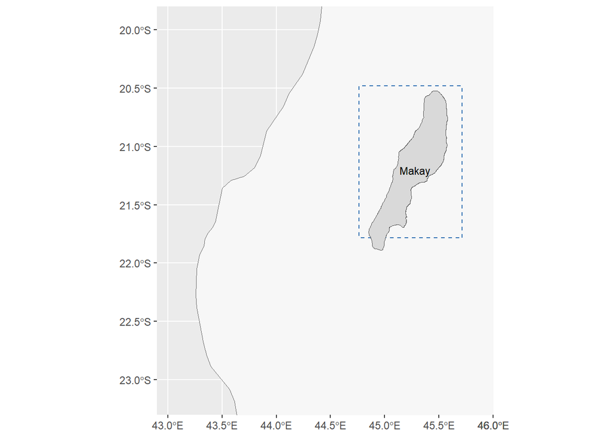

Figure 1: The Makay boundary (WDPA Nov 2026, status Proposed, grey) and the Alentours Makay outline (blue dashed), with Madagascar’s national border, in the study box used for the later maps.

```r
ggplot() +
  geom_sf(data = mdg_border, fill = "grey97", color = "grey40", linewidth = 0.3) +
  geom_sf(data = alentours, fill = NA, color = "#2b6cb0", linetype = "dashed", linewidth = 0.5) +
  geom_sf(data = makay, fill = "grey85", color = "grey30") +
  geom_sf_text(data = makay_label, aes(label = NAME), size = 3) +
  coord_sf(xlim = c(42.9, 46), ylim = c(-23.3, -19.8), expand = FALSE) +
  labs(x = NULL, y = NULL)
```

## Accessibility check

Each endpoint is tested with a HEAD request. A status of 200 means the resource answered; it does not confirm the data content, which is checked further below.

```r
check_url <- function(url) {
  tryCatch(
    request(url) |>
      req_method("HEAD") |>
      req_timeout(60) |>
      req_error(is_error = \(resp) FALSE) |>
      req_perform() |>
      resp_status(),
    error = \(e) NA_integer_
  )
}

endpoints <- tribble(
  ~source, ~resource, ~url,
  "GHCN-Daily", "Station list", "https://www.ncei.noaa.gov/pub/data/ghcn/daily/ghcnd-stations.txt",
  "GHCN-Daily", "Inventory by element", "https://www.ncei.noaa.gov/pub/data/ghcn/daily/ghcnd-inventory.txt",
  "GHCN-Daily", "Per-station CSV (Ranohira)", "https://www.ncei.noaa.gov/data/global-historical-climatology-network-daily/access/MAM00067152.csv",
  "Meteostat", "Station index (bulk JSON)", "https://bulk.meteostat.net/v2/stations/full.json.gz",
  "Meteostat", "Daily bulk file (Ranohira)", "https://bulk.meteostat.net/v2/daily/67152.csv.gz",
  "Meteo Madagascar", "IRI data library home", "https://map.meteomadagascar.mg/",
  "Meteo Madagascar", "Monthly rainfall branch", "https://map.meteomadagascar.mg/SOURCES/.Madagascar_v3/.ALL/.monthly/.rainfall/",
  "WorldClim", "Historical monthly precipitation 2010-2019 (5 arc-min)", "https://geodata.ucdavis.edu/climate/worldclim/2_1/hist/cts4.09/wc2.1_cruts4.09_5m_prec_2010-2019.zip"
)

endpoints |>
  mutate(http_status = map_int(url, check_url)) |>
  select(source, resource, http_status, url) |>
  kable()
```

Table 1: HTTP status of each source endpoint, tested at the time of the analysis.

| source | resource | http_status | url |
| --- | --- | --- | --- |
| GHCN-Daily | Station list | 200 | https://www.ncei.noaa.gov/pub/data/ghcn/daily/ghcnd-stations.txt |
| GHCN-Daily | Inventory by element | 200 | https://www.ncei.noaa.gov/pub/data/ghcn/daily/ghcnd-inventory.txt |
| GHCN-Daily | Per-station CSV (Ranohira) | 200 | https://www.ncei.noaa.gov/data/global-historical-climatology-network-daily/access/MAM00067152.csv |
| Meteostat | Station index (bulk JSON) | 200 | https://bulk.meteostat.net/v2/stations/full.json.gz |
| Meteostat | Daily bulk file (Ranohira) | 200 | https://bulk.meteostat.net/v2/daily/67152.csv.gz |
| Meteo Madagascar | IRI data library home | 200 | https://map.meteomadagascar.mg/ |
| Meteo Madagascar | Monthly rainfall branch | 200 | https://map.meteomadagascar.mg/SOURCES/.Madagascar_v3/.ALL/.monthly/.rainfall/ |
| WorldClim | Historical monthly precipitation 2010-2019 (5 arc-min) | 200 | https://geodata.ucdavis.edu/climate/worldclim/2_1/hist/cts4.09/wc2.1_cruts4.09_5m_prec_2010-2019.zip |

### Station metadata

Both station indexes are downloaded in full and filtered to Madagascar. GHCN-Daily is filtered to stations with a PRCP record in the inventory.

```r
ghcn_stations_file <- fetch(
  "https://www.ncei.noaa.gov/pub/data/ghcn/daily/ghcnd-stations.txt",
  file.path(raw_dir, "ghcnd-stations.txt")
)
ghcn_inventory_file <- fetch(
  "https://www.ncei.noaa.gov/pub/data/ghcn/daily/ghcnd-inventory.txt",
  file.path(raw_dir, "ghcnd-inventory.txt")
)
meteostat_index_file <- fetch(
  "https://bulk.meteostat.net/v2/stations/full.json.gz",
  file.path(raw_dir, "meteostat-stations-full.json.gz")
)

ghcn_stations <- read_fwf(
  ghcn_stations_file,
  fwf_positions(c(1, 13, 22, 32, 42), c(11, 20, 30, 37, 71),
    col_names = c("id", "lat", "lon", "elev", "name")
  ),
  show_col_types = FALSE
)

ghcn_prcp <- read_fwf(
  ghcn_inventory_file,
  fwf_positions(c(1, 32, 37, 42), c(11, 35, 40, 45),
    col_names = c("id", "element", "first_year", "last_year")
  ),
  show_col_types = FALSE
) |>
  filter(element == "PRCP")

ms_index <- fromJSON(
  paste(readLines(gzfile(meteostat_index_file), warn = FALSE), collapse = ""),
  flatten = TRUE
)
```

```r
dist_to_pa_km <- function(df) {
  pts <- st_as_sf(df, coords = c("lon", "lat"), crs = 4326) |>
    st_transform(utm_crs)
  df |>
    mutate(dist_km = as.numeric(st_distance(pts, makay_utm)) / 1000)
}

ghcn_candidates <- ghcn_stations |>
  filter(str_starts(id, "MA")) |>
  inner_join(ghcn_prcp, by = "id") |>
  transmute(
    source = "GHCN-Daily",
    station_id = id,
    wmo = str_sub(id, -5),
    name = str_to_title(str_trim(name)),
    lon, lat, elev,
    first_year, last_year
  ) |>
  dist_to_pa_km()

ms_candidates <- ms_index |>
  filter(country == "MG", str_detect(id, "^[0-9]{5}$"), !is.na(inventory.daily.start)) |>
  transmute(
    source = "Meteostat",
    station_id = id,
    wmo = id,
    name = name.en,
    lon = location.longitude,
    lat = location.latitude,
    elev = location.elevation,
    first_year = year(as.Date(inventory.daily.start)),
    last_year = year(as.Date(inventory.daily.end))
  ) |>
  dist_to_pa_km()

station_meta <- bind_rows(ghcn_candidates, ms_candidates) |>
  filter(dist_km <= radius_km) |>
  arrange(dist_km)

station_meta |>
  transmute(
    Source = source,
    Station = name,
    `ID` = station_id,
    `Distance to Makay (km)` = round(dist_km),
    `Elevation (m)` = elev,
    `Record start` = first_year,
    `Record end (metadata)` = last_year
  ) |>
  kable(caption = "Stations within 400 km of the Makay boundary, by source. Distances are measured from the boundary, not the centroid.")
```

Stations within 400 km of the Makay boundary, by source. Distances are measured from the boundary, not the centroid.

| Source | Station | ID | Distance to Makay (km) | Elevation (m) | Record start | Record end (metadata) |
| --- | --- | --- | --- | --- | --- | --- |
| GHCN-Daily | Ranohira | MAM00067152 | 85 | 824.0 | 1973 | 2020 |
| Meteostat | Ranohira | 67152 | 85 | 824.0 | 1973 | 2020 |
| GHCN-Daily | Morondava | MAM00067117 | 114 | 9.1 | 1973 | 2020 |
| Meteostat | Morondava | 67117 | 115 | 7.0 | 1973 | 2020 |
| GHCN-Daily | Morombe | MAM00067131 | 153 | 4.9 | 1973 | 2022 |
| Meteostat | Morombe | 67131 | 154 | 5.0 | 1973 | 2023 |
| Meteostat | Fianarantsoa | 67137 | 166 | 1115.0 | 1973 | 2023 |
| GHCN-Daily | Fianarantsoa | MAM00067137 | 167 | 1115.0 | 1973 | 2023 |
| Meteostat | Antsirabe | 67107 | 180 | 1523.0 | 1974 | 2027 |
| GHCN-Daily | Antsirabe | MAM00067107 | 180 | 1532.0 | 1974 | 2025 |
| GHCN-Daily | Toliara | MA000067161 | 206 | 8.0 | 1973 | 2023 |
| Meteostat | Tulear | 67161 | 206 | 8.0 | 1973 | 2027 |
| GHCN-Daily | Antananarivo / Ville | MAM00067085 | 279 | 1310.0 | 2011 | 2021 |
| Meteostat | Ambohimanarina | 67085 | 279 | 1310.0 | 2011 | 2021 |
| GHCN-Daily | Antananarivo/Ivato | MA000067083 | 283 | 1276.0 | 1973 | 2025 |
| Meteostat | Antananarivo / Ivato | 67083 | 283 | 1279.0 | 1973 | 2027 |
| Meteostat | Mananjary | 67143 | 291 | 5.0 | 1973 | 2023 |
| GHCN-Daily | Mananjary | MA000067143 | 291 | 6.0 | 1973 | 2023 |
| GHCN-Daily | Farafangana | MAM00067157 | 299 | 7.9 | 1973 | 2015 |
| Meteostat | Farafangana | 67157 | 300 | 8.0 | 1973 | 2015 |
| Meteostat | Maintirano | 67073 | 311 | 23.0 | 1973 | 2017 |
| GHCN-Daily | Maintirano | MAM00067073 | 311 | 23.0 | 1973 | 2017 |
| Meteostat | Mahanoro | 67113 | 349 | 5.0 | 1973 | 2019 |
| GHCN-Daily | Mahanoro | MAM00067113 | 349 | 5.0 | 1974 | 2019 |

Beroroha, the station mentioned in the brief, does not appear in either index for Madagascar, so no station record is available for it from these sources. The three stations closest to Makay, Ranohira, Morondava and Morombe, are the focus of the rest of the document.

```r
set.seed(4817)
station_pts <- station_meta |>
  st_as_sf(coords = c("lon", "lat"), crs = 4326, remove = FALSE) |>
  st_transform(utm_crs) |>
  # Jitter by up to ~3 km so that GHCN and Meteostat points at one station stay visible
  st_jitter(amount = 3000) |>
  st_transform(4326) |>
  mutate(
    focus = wmo %in% focus_wmo,
    station = names(focus_wmo)[match(wmo, focus_wmo)]
  )
```

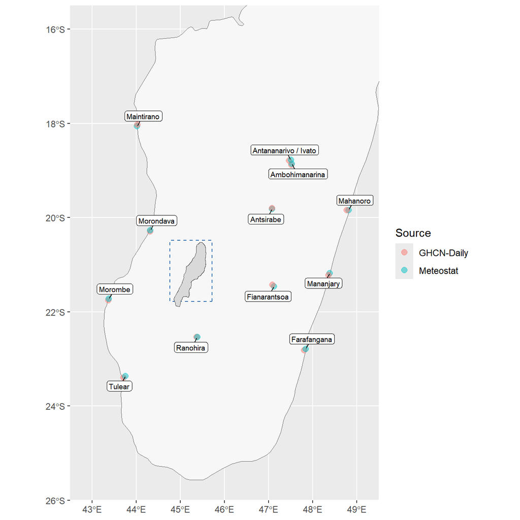

Figure 2: Stations within 400 km of the Makay boundary (GHCN-Daily and Meteostat), with Makay outlined. Points are jittered by up to about 3 km and drawn semi-transparent, so the two sources at one station remain visible. Positions are approximate.

```r
# ggrepel has no sf layers, so labels are placed on plain X/Y coordinates
sf_xy <- function(x) bind_cols(st_drop_geometry(x), as_tibble(st_coordinates(x)))

station_labels_xy <- station_pts |>
  arrange(desc(source)) |>
  group_by(wmo) |>
  slice(1) |>
  ungroup() |>
  sf_xy()

ggplot() +
  geom_sf(data = mdg_border, fill = "grey97", color = "grey40", linewidth = 0.3) +
  geom_sf(data = alentours, fill = NA, color = "#2b6cb0", linetype = "dashed", linewidth = 0.5) +
  geom_sf(data = makay, fill = "grey85", color = "grey30") +
  geom_sf(data = station_pts, aes(color = source), alpha = 0.5, size = 2.5) +
  geom_label_repel(
    data = station_labels_xy, aes(X, Y, label = name),
    size = 2.5, max.overlaps = Inf, min.segment.length = 0, label.padding = 0.15
  ) +
  coord_sf(xlim = c(42.5, 49.5), ylim = c(-26, -15.5), expand = FALSE) +
  labs(color = "Source", x = NULL, y = NULL)
```

## Focus period: November 2019 to October 2020

### Download of station records

```r
ghcn_daily <- station_meta |>
  filter(source == "GHCN-Daily") |>
  pull(station_id) |>
  map(\(id) {
    file <- fetch(
      paste0("https://www.ncei.noaa.gov/data/global-historical-climatology-network-daily/access/", id, ".csv"),
      file.path(raw_dir, paste0("ghcn_", id, ".csv"))
    )
    read_csv(file, col_select = c(STATION, DATE, PRCP), show_col_types = FALSE)
  }) |>
  list_rbind()

ms_daily_cols <- c("date", "tavg", "tmin", "tmax", "prcp", "snow", "wdir", "wspd", "wpgt", "pres", "tsun")

ms_daily <- station_meta |>
  filter(source == "Meteostat") |>
  pull(station_id) |>
  map(\(id) {
    file <- fetch(
      paste0("https://bulk.meteostat.net/v2/daily/", id, ".csv.gz"),
      file.path(raw_dir, paste0("meteostat_", id, ".csv.gz"))
    )
    read_csv(file,
      col_names = ms_daily_cols,
      col_types = cols(.default = col_double(), date = col_date()),
      show_col_types = FALSE
    ) |>
      select(date, prcp) |>
      mutate(station_id = id)
  }) |>
  list_rbind()

station_labels <- station_meta |>
  arrange(desc(source)) |>
  distinct(wmo, .keep_all = TRUE) |>
  transmute(wmo, label = paste0(name, " (", wmo, ")"))

daily <- bind_rows(
  ghcn_daily |>
    transmute(
      source = "GHCN-Daily",
      station_id = str_sub(STATION, 1, 11),
      date = DATE,
      # GHCN-Daily stores PRCP in tenths of mm
      prcp = PRCP / 10
    ),
  ms_daily |>
    transmute(source = "Meteostat", station_id, date, prcp)
) |>
  inner_join(
    station_meta |> select(source, station_id, wmo),
    by = c("source", "station_id")
  ) |>
  left_join(station_labels, by = "wmo") |>
  rename(name = label)
```

The GHCN per-station files use the full 11-character ID, which is what `station_id` holds, so the join to the metadata uses the same key. Meteostat IDs are the 5-digit WMO numbers, which match the last five characters of the GHCN IDs. The `wmo` column links the two sources for the same physical station.

### Observation counts in the window

The window is the hydrological year 2019/20. Observed days per month are counted from the daily records, by source. A month’s total is only a usable comparison when most of its days are observed; here no month reaches 80% at any of the three stations.

```r
focus_monthly <- expand_grid(
  source = c("GHCN-Daily", "Meteostat"),
  station = factor(names(focus_wmo), levels = names(focus_wmo)),
  month = focus_months
) |>
  left_join(
    daily |>
      filter(wmo %in% focus_wmo, date >= min(focus_months), date < focus_end) |>
      mutate(
        station = factor(names(focus_wmo)[match(wmo, focus_wmo)], levels = names(focus_wmo)),
        month = floor_date(date, "month")
      ) |>
      group_by(source, station, month) |>
      summarise(
        days_obs = sum(!is.na(prcp)),
        obs_sum_mm = sum(prcp, na.rm = TRUE),
        .groups = "drop"
      ),
    by = c("source", "station", "month")
  ) |>
  mutate(
    days_obs = replace_na(days_obs, 0L),
    obs_sum_mm = if_else(days_obs == 0, NA_real_, obs_sum_mm)
  )

focus_monthly |>
  mutate(month_lab = mlab(month)) |>
  select(station, source, month_lab, days_obs) |>
  pivot_wider(names_from = month_lab, values_from = days_obs) |>
  kable(caption = "Days with a non-missing PRCP value per month, November 2019 to October 2020, by station and source. Out of about 30 days per month, no month is near complete at any station.")
```

Days with a non-missing PRCP value per month, November 2019 to October 2020, by station and source. Out of about 30 days per month, no month is near complete at any station.

| station | source | Nov 2019 | Dec 2019 | Jan 2020 | Feb 2020 | Mar 2020 | Apr 2020 | May 2020 | Jun 2020 | Jul 2020 | Aug 2020 | Sep 2020 | Oct 2020 |
| --- | --- | --- | --- | --- | --- | --- | --- | --- | --- | --- | --- | --- | --- |
| Ranohira | GHCN-Daily | 3 | 8 | 20 | 5 | 4 | 5 | 2 | 2 | 2 | 0 | 4 | 9 |
| Morondava | GHCN-Daily | 4 | 8 | 18 | 12 | 0 | 0 | 0 | 4 | 2 | 0 | 0 | 0 |
| Morombe | GHCN-Daily | 0 | 0 | 0 | 0 | 0 | 0 | 0 | 0 | 0 | 0 | 0 | 0 |
| Ranohira | Meteostat | 3 | 8 | 20 | 5 | 4 | 5 | 2 | 2 | 2 | 0 | 4 | 9 |
| Morondava | Meteostat | 4 | 8 | 18 | 12 | 0 | 0 | 0 | 4 | 2 | 0 | 0 | 0 |
| Morombe | Meteostat | 0 | 0 | 0 | 0 | 0 | 0 | 0 | 0 | 0 | 0 | 0 | 0 |

### WorldClim monthly values

WorldClim’s historical monthly precipitation is interpolated from station data (CRU TS 4.09), at 5 arc-minute resolution (about 9 km). It is not a station record, so it is used here only as a cross-check. The 1970-2000 normals come from the same product family at 30 arc-second resolution.

```r
wc_url <- "https://geodata.ucdavis.edu/climate/worldclim/2_1/hist/cts4.09/"
wc_zips <- c(
  "wc2.1_cruts4.09_5m_prec_2010-2019.zip",
  "wc2.1_cruts4.09_5m_prec_2020-2024.zip"
)
wc_dir <- file.path(raw_dir, "worldclim")
wc_month_dir <- file.path(wc_dir, "monthly")
dir.create(wc_month_dir, recursive = TRUE, showWarnings = FALSE)

walk(wc_zips, \(z) fetch(paste0(wc_url, z), file.path(wc_dir, z)))

wc_tifs <- sprintf("wc2.1_cruts4.09_5m_prec_%s.tif", format(focus_months, "%Y-%m"))
walk2(wc_tifs, if_else(year(focus_months) == 2019, wc_zips[1], wc_zips[2]), \(tif, z) {
  if (!file.exists(file.path(wc_month_dir, tif))) {
    unzip(file.path(wc_dir, z), files = tif, exdir = wc_month_dir)
  }
})

wc_month <- rast(file.path(wc_month_dir, wc_tifs)) |>
  crop(ext(40, 52, -26, -11))
names(wc_month) <- format(focus_months, "%Y-%m")

nrm <- worldclim_country("Madagascar", var = "prec", path = wc_dir)

focus_pts_v <- station_meta |>
  filter(wmo %in% focus_wmo) |>
  arrange(source) |>
  distinct(wmo, .keep_all = TRUE) |>
  transmute(station = names(focus_wmo)[match(wmo, focus_wmo)], lon, lat) |>
  arrange(match(station, names(focus_wmo)))

focus_vect <- vect(focus_pts_v, geom = c("lon", "lat"), crs = "EPSG:4326")

wc_station <- as_tibble(terra::extract(wc_month, focus_vect)) |>
  mutate(station = focus_pts_v$station[ID]) |>
  select(-ID) |>
  pivot_longer(-station, names_to = "month", values_to = "wc_2019_20_mm") |>
  mutate(month = ym(month))

normal_station <- as_tibble(terra::extract(nrm, focus_vect)) |>
  mutate(station = focus_pts_v$station[ID]) |>
  select(-ID) |>
  pivot_longer(-station, names_to = "layer", values_to = "wc_normal_mm") |>
  mutate(m = as.integer(str_extract(layer, "\\d+$"))) |>
  select(station, m, wc_normal_mm)

wc_focus <- wc_station |>
  mutate(m = month(month)) |>
  left_join(normal_station, by = c("station", "m")) |>
  select(station, month, wc_2019_20_mm, wc_normal_mm)
```

```r
wc_check <- focus_monthly |>
  filter(source == "GHCN-Daily", days_obs > 0) |>
  left_join(wc_focus, by = c("station", "month")) |>
  mutate(`Observed sum above WorldClim` = if_else(obs_sum_mm > wc_2019_20_mm, "Yes", "No"))

wc_check |>
  transmute(
    Station = station,
    Month = mlab(month),
    `Days observed` = days_obs,
    `Observed sum (mm, lower bound)` = round(obs_sum_mm, 1),
    `WorldClim 2019/20 (mm)` = round(wc_2019_20_mm, 1),
    `WorldClim 1970-2000 (mm)` = round(wc_normal_mm, 1),
    `Observed sum above WorldClim` = `Observed sum above WorldClim`
  ) |>
  kable()
```

Table 2: Observed monthly sums (GHCN-Daily, observed days only) against WorldClim for the same station and month. A sum over fewer than all days is a lower bound on the monthly total, so an observed sum above the WorldClim value points to a disagreement. Months with no observed day are omitted.

| Station | Month | Days observed | Observed sum (mm, lower bound) | WorldClim 2019/20 (mm) | WorldClim 1970-2000 (mm) | Observed sum above WorldClim |
| --- | --- | --- | --- | --- | --- | --- |
| Ranohira | Nov 2019 | 3 | 99.1 | 93.2 | 88 | Yes |
| Ranohira | Dec 2019 | 8 | 57.9 | 207.2 | 150 | No |
| Ranohira | Jan 2020 | 20 | 178.6 | 166.5 | 200 | Yes |
| Ranohira | Feb 2020 | 5 | 94.0 | 129.1 | 170 | No |
| Ranohira | Mar 2020 | 4 | 28.3 | 91.3 | 96 | No |
| Ranohira | Apr 2020 | 5 | 4.3 | 29.0 | 34 | No |
| Ranohira | May 2020 | 2 | 25.9 | 24.4 | 18 | Yes |
| Ranohira | Jun 2020 | 2 | 13.3 | 6.7 | 5 | Yes |
| Ranohira | Jul 2020 | 2 | 0.8 | 3.1 | 3 | No |
| Ranohira | Sep 2020 | 4 | 5.6 | 11.9 | 8 | No |
| Ranohira | Oct 2020 | 9 | 17.2 | 42.5 | 37 | No |
| Morondava | Nov 2019 | 4 | 27.2 | 27.8 | 27 | No |
| Morondava | Dec 2019 | 8 | 93.2 | 156.8 | 158 | No |
| Morondava | Jan 2020 | 18 | 183.9 | 252.2 | 245 | No |
| Morondava | Feb 2020 | 12 | 26.1 | 194.2 | 200 | No |
| Morondava | Jun 2020 | 4 | 14.0 | 1.8 | 2 | Yes |
| Morondava | Jul 2020 | 2 | 1.0 | 2.0 | 2 | No |

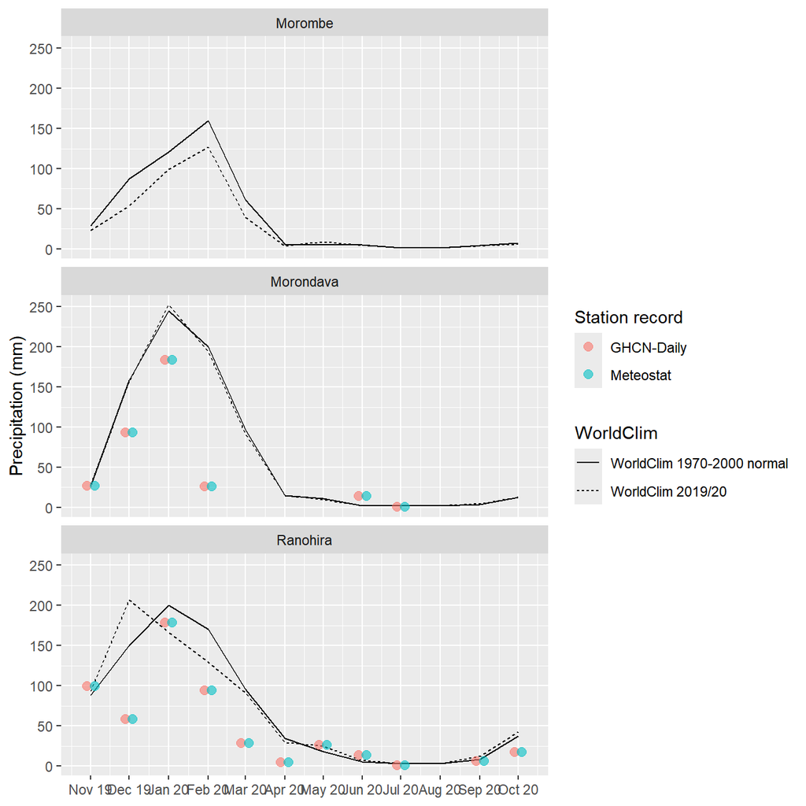

Figure 3: Monthly precipitation at the three closest stations, November 2019 to October 2020. Points are the sum of observed days only (lower bounds on the monthly total); lines are WorldClim for the same months and the WorldClim 1970-2000 normal. Morombe has no observed day in the window, so only its WorldClim lines are shown.

```r
wc_long <- wc_focus |>
  pivot_longer(
    c(wc_2019_20_mm, wc_normal_mm),
    names_to = "series",
    values_to = "mm"
  ) |>
  mutate(series = if_else(series == "wc_2019_20_mm", "WorldClim 2019/20", "WorldClim 1970-2000 normal"))

focus_monthly |>
  filter(!is.na(obs_sum_mm)) |>
  ggplot() +
  geom_line(data = wc_long, aes(month, mm, linetype = series)) +
  # Dodged so that the two sources at one station remain visible
  geom_point(aes(month, obs_sum_mm, color = source),
    alpha = 0.6, size = 2.5, position = position_dodge(width = 12)
  ) +
  facet_wrap(~station, ncol = 1) +
  scale_x_date(breaks = focus_months, labels = \(x) mlab(x) |> str_replace(" 20(\\d\\d)$", " \\1")) +
  labs(x = NULL, y = "Precipitation (mm)", color = "Station record", linetype = "WorldClim")
```

## Gridded rainfall over the Makay

No station lies inside or adjacent to the Makay boundary, so the polygon mean of gridded products is the only estimate of rainfall over the massif itself. Three products are compared over the same polygon and the same window: ENACTS v4 daily, CHIRPS v2.0 monthly and WorldClim historical monthly, with the WorldClim 1970-2000 normal for reference. Polygon means use cell-overlap weights.

### ENACTS v4

ENACTS (Enhanced National Climate Services) products are built by national meteorological services with the IRI Data Library; for Madagascar they are served through the Meteo Madagascar maproom (map.meteomadagascar.mg). The file `data.nc` at the repository root is the daily rainfall layer (variable `rfe`, unit mm) of Madagascar ENACTS v4, downloaded from the maproom for this analysis. It covers 44.49-45.81 degrees east and 20.27-22.22 degrees south at 0.0375 degrees (about 4 km), with 366 daily layers from 1 November 2019 to 31 October 2020 on a julian-day time axis. ENACTS grids are produced by blending national station observations with satellite rainfall estimates; the exact v4 station network and satellite source are not stated in the file metadata, and the IRI Data Library catalog now requires sign-in, so they could not be verified here. Over the Makay box, no day and no cell is missing in the window.

```r
enacts_file <- "data.nc"
stopifnot(file.exists(enacts_file))
enacts <- rast(enacts_file)

# IRI julian-day time axis: JD 2440588 is 1970-01-01
enacts_dates <- metags(enacts) |>
  filter(name == "NETCDF_DIM_T_VALUES") |>
  pull(value) |>
  str_remove_all("[{}]") |>
  str_split_1(",") |>
  as.numeric() |>
  (\(jd) as.Date(jd - 2440588, origin = "1970-01-01"))()
stopifnot(length(enacts_dates) == nlyr(enacts), all(diff(enacts_dates) == 1))
names(enacts) <- format(enacts_dates, "%Y-%m-%d")
```

```r
# Daily mean over the Makay polygon, weighted by each cell's overlap with the polygon
# (extract returns the weights in a trailing column named "weight")
enacts_ex <- terra::extract(enacts, makay, weights = TRUE, exact = FALSE)
enacts_layers <- as.matrix(enacts_ex[setdiff(names(enacts_ex), c("ID", "weight"))])
enacts_daily <- tibble(
  date = enacts_dates,
  prcp_mm = apply(enacts_layers, 2, \(v) weighted.mean(v, enacts_ex$weight, na.rm = TRUE))
)

dir.create("data/derived", showWarnings = FALSE)
write_csv(enacts_daily, "data/derived/makay_enacts_daily.csv")

enacts_monthly <- enacts_daily |>
  mutate(month = floor_date(date, "month")) |>
  summarise(mm = sum(prcp_mm), .by = month)
```

The daily series is exported to `data/derived/makay_enacts_daily.csv`, one row per day with columns `date` and `prcp_mm` (mm per day, area-weighted polygon mean).

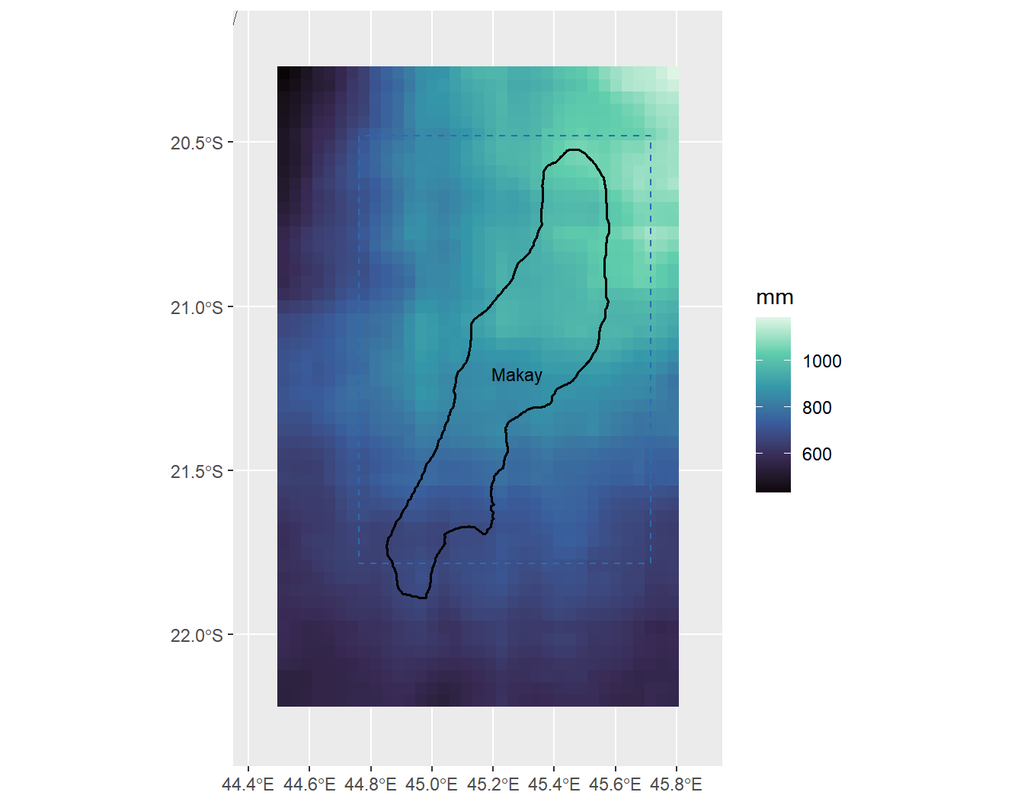

Figure 4: ENACTS v4 total rainfall, November 2019 to October 2020, at 0.0375 degrees (about 4 km), with the Makay boundary and the Alentours outline. The product covers the downloaded box only.

```r
enacts_total <- app(enacts, sum) |>
  crop(ext(42.9, 46, -23.3, -19.8))
enacts_map_df <- as.data.frame(enacts_total, xy = TRUE) |>
  set_names(c("x", "y", "mm"))

ggplot() +
  geom_raster(data = enacts_map_df, aes(x, y, fill = mm)) +
  geom_sf(data = mdg_border, fill = NA, color = "grey30", linewidth = 0.3) +
  geom_sf(data = alentours, fill = NA, color = "#2b6cb0", linetype = "dashed", linewidth = 0.5) +
  geom_sf(data = makay, fill = NA, color = "black", linewidth = 0.6) +
  geom_sf_text(data = makay_label, aes(label = NAME), size = 3) +
  coord_sf(xlim = c(44.35, 45.95), ylim = c(-22.4, -20.1), expand = FALSE) +
  scale_fill_viridis_c(name = "mm", option = "mako") +
  labs(x = NULL, y = NULL)
```

At this resolution the map resolves a marked gradient across the massif, with higher totals to the north-east and lower totals to the south-west.

### CHIRPS

CHIRPS v2.0 monthly precipitation, 0.05 degree. The twelve monthly GeoTIFFs for the window were taken from a local S3 copy of the CHC product archive (`s3://projet-betsaka/PA-impact-deforestation/mapme/chirps/`), since the original CHC paths and the ERDDAP mirror used by `climateR` did not answer during testing.

```r
chirps_dir <- file.path(raw_dir, "chirps")
chirps_ym <- format(focus_months, "%Y.%m")
chirps_fetch <- function(ym) {
  file <- file.path(chirps_dir, sprintf("chirps-v2.0.%s.tif", ym))
  if (!file.exists(file)) {
    s3 <- paws.storage::s3()
    o <- s3$get_object(
      Bucket = "projet-betsaka",
      Key = paste0("PA-impact-deforestation/mapme/chirps/chirps-v2.0.", ym, ".tif")
    )
    writeBin(o$Body, file)
  }
  file
}
chirps_files <- map(chirps_ym, chirps_fetch)
chirps_stack <- rast(unlist(chirps_files))
names(chirps_stack) <- format(focus_months, "%Y-%m")
```

```r
e_makay <- terra::extract(chirps_stack, makay, weights = TRUE, exact = FALSE)
wts <- e_makay$weight
makay_chirps <- sapply(names(chirps_stack), \(n) weighted.mean(e_makay[[n]], wts))
```

### WorldClim

The WorldClim historical monthly product for the window (5 arc-minute, CRU TS 4.09 based) and the 1970-2000 normal (30 arc-second), averaged over the Makay polygon with exact cell fractions.

```r
makay_v <- vect(makay)
makay_wc_1920 <- as.numeric(terra::extract(wc_month, makay_v, fun = mean, na.rm = TRUE, exact = TRUE)[1, -1])
makay_normal <- as.numeric(terra::extract(nrm, makay_v, fun = mean, na.rm = TRUE, exact = TRUE)[1, -1])
```

### Monthly comparison and annual totals

```r
gridded_cmp <- tibble(
  Month = focus_months,
  `ENACTS v4 (mm)` = enacts_monthly$mm,
  `CHIRPS (mm)` = makay_chirps,
  `WorldClim 2019/20 (mm)` = makay_wc_1920
)

gridded_cmp |>
  mutate(Month = mlab(Month), across(where(is.numeric), \(x) round(x, 1))) |>
  bind_rows(gridded_cmp |> summarise(Month = "Total", across(where(is.numeric), \(x) round(sum(x), 1)))) |>
  kable()
```

Table 3: Monthly rainfall averaged over the Makay polygon, November 2019 to October 2020, from ENACTS v4, CHIRPS and WorldClim. The last row is the twelve-month total.

| Month | ENACTS v4 (mm) | CHIRPS (mm) | WorldClim 2019/20 (mm) |
| --- | --- | --- | --- |
| Nov 2019 | 112.6 | 116.8 | 79.4 |
| Dec 2019 | 122.2 | 148.7 | 223.9 |
| Jan 2020 | 267.2 | 296.3 | 301.0 |
| Feb 2020 | 248.0 | 205.3 | 232.8 |
| Mar 2020 | 67.9 | 65.7 | 129.0 |
| Apr 2020 | 7.5 | 10.8 | 22.4 |
| May 2020 | 5.9 | 6.9 | 7.5 |
| Jun 2020 | 6.5 | 3.4 | 3.5 |
| Jul 2020 | 1.9 | 1.6 | 3.5 |
| Aug 2020 | 2.1 | 1.9 | 3.7 |
| Sep 2020 | 2.5 | 4.7 | 6.8 |
| Oct 2020 | 27.9 | 15.8 | 31.2 |
| Total | 872.2 | 877.9 | 1044.9 |

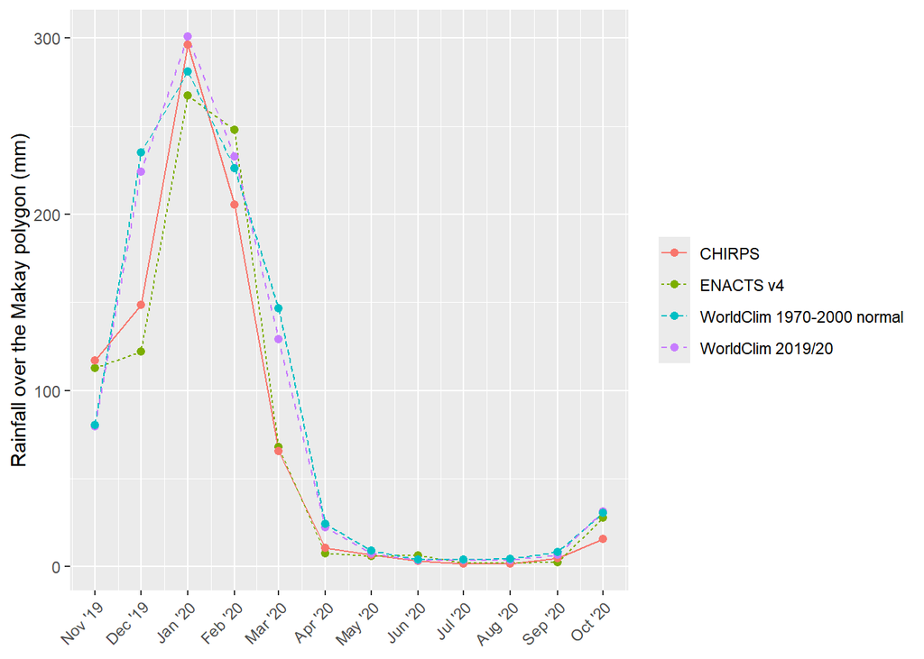

```r
tibble(
  month = focus_months,
  `ENACTS v4` = enacts_monthly$mm,
  CHIRPS = makay_chirps,
  `WorldClim 2019/20` = makay_wc_1920,
  `WorldClim 1970-2000 normal` = makay_normal[month(focus_months)]
) |>
  pivot_longer(-month, names_to = "product", values_to = "mm") |>
  ggplot(aes(month, mm, color = product, linetype = product)) +
  geom_line() +
  geom_point(size = 1.8) +
  scale_x_date(breaks = focus_months, labels = \(x) mlab(x) |> str_replace(" 20(\\d\\d)$", " '\\1")) +
  labs(x = NULL, y = "Rainfall over the Makay polygon (mm)", color = NULL, linetype = NULL) +
  theme(axis.text.x = element_text(angle = 45, hjust = 1))
```

```r
enacts_total_mm <- sum(enacts_monthly$mm)
chirps_total_mm <- sum(makay_chirps)
wc_total_mm <- sum(makay_wc_1920)
en_ch_r <- cor(enacts_monthly$mm, makay_chirps)
en_ch_maxdiff <- max(abs(enacts_monthly$mm - makay_chirps))
en_wc_gap <- 100 * (enacts_total_mm - wc_total_mm) / wc_total_mm
en_ch_gap <- 100 * (enacts_total_mm - chirps_total_mm) / chirps_total_mm
```

## Coverage over 1991-2020

Coverage is measured as the share of calendar days with a non-missing precipitation value. Years are counted as complete at 90% of days observed; months at 80%. These thresholds are working choices. Station names differ between sources for WMO 67085 (GHCN: Antananarivo/Ville; Meteostat: Ambohimanarina), so each station is labelled from its Meteostat name where one exists.

```r
coverage <- daily |>
  group_by(source, name, wmo) |>
  summarise(
    first_obs = min(date[!is.na(prcp)]),
    last_obs = max(date[!is.na(prcp)]),
    pct_obs_1991_2020 = round(100 * sum(!is.na(prcp) & year(date) %in% clim_years) / n_clim_days, 1),
    .groups = "drop"
  ) |>
  arrange(desc(pct_obs_1991_2020))

coverage |> kable()
```

Table 4: Share of days observed in 1991-2020 by station and source, with the first and last observed day.

| source | name | wmo | first_obs | last_obs | pct_obs_1991_2020 |
| --- | --- | --- | --- | --- | --- |
| GHCN-Daily | Antananarivo / Ivato (67083) | 67083 | 1973-06-01 | 2025-08-15 | 47.6 |
| Meteostat | Antananarivo / Ivato (67083) | 67083 | 1973-06-01 | 2026-03-21 | 47.6 |
| GHCN-Daily | Fianarantsoa (67137) | 67137 | 1973-02-20 | 2023-12-22 | 41.5 |
| Meteostat | Fianarantsoa (67137) | 67137 | 1973-02-20 | 2026-03-21 | 41.5 |
| GHCN-Daily | Mahanoro (67113) | 67113 | 1974-12-23 | 2019-06-17 | 33.9 |
| Meteostat | Mahanoro (67113) | 67113 | 1974-12-23 | 2026-03-21 | 33.9 |
| GHCN-Daily | Farafangana (67157) | 67157 | 1973-06-27 | 2015-02-19 | 22.5 |
| Meteostat | Farafangana (67157) | 67157 | 1973-06-27 | 2026-03-21 | 22.5 |
| GHCN-Daily | Morondava (67117) | 67117 | 1973-06-03 | 2020-12-29 | 19.6 |
| Meteostat | Morondava (67117) | 67117 | 1973-06-03 | 2026-03-21 | 19.6 |
| GHCN-Daily | Tulear (67161) | 67161 | 1973-06-16 | 2023-05-24 | 18.9 |
| Meteostat | Tulear (67161) | 67161 | 1973-06-16 | 2026-03-21 | 18.9 |
| GHCN-Daily | Mananjary (67143) | 67143 | 1973-05-11 | 2023-02-13 | 18.6 |
| Meteostat | Mananjary (67143) | 67143 | 1973-05-11 | 2026-03-21 | 18.6 |
| GHCN-Daily | Antsirabe (67107) | 67107 | 1974-03-14 | 2025-08-18 | 15.9 |
| Meteostat | Antsirabe (67107) | 67107 | 1974-03-14 | 2026-03-21 | 15.9 |
| GHCN-Daily | Ranohira (67152) | 67152 | 1973-07-05 | 2020-11-14 | 15.4 |
| Meteostat | Ranohira (67152) | 67152 | 1973-07-05 | 2026-03-21 | 15.4 |
| GHCN-Daily | Maintirano (67073) | 67073 | 1973-06-15 | 2017-04-02 | 10.6 |
| Meteostat | Maintirano (67073) | 67073 | 1973-06-15 | 2026-03-21 | 10.6 |
| GHCN-Daily | Morombe (67131) | 67131 | 1973-08-31 | 2022-02-23 | 3.9 |
| Meteostat | Morombe (67131) | 67131 | 1973-08-31 | 2026-03-21 | 3.9 |
| GHCN-Daily | Ambohimanarina (67085) | 67085 | 2011-04-22 | 2021-03-11 | 2.8 |
| Meteostat | Ambohimanarina (67085) | 67085 | 2011-04-22 | 2024-03-10 | 2.8 |

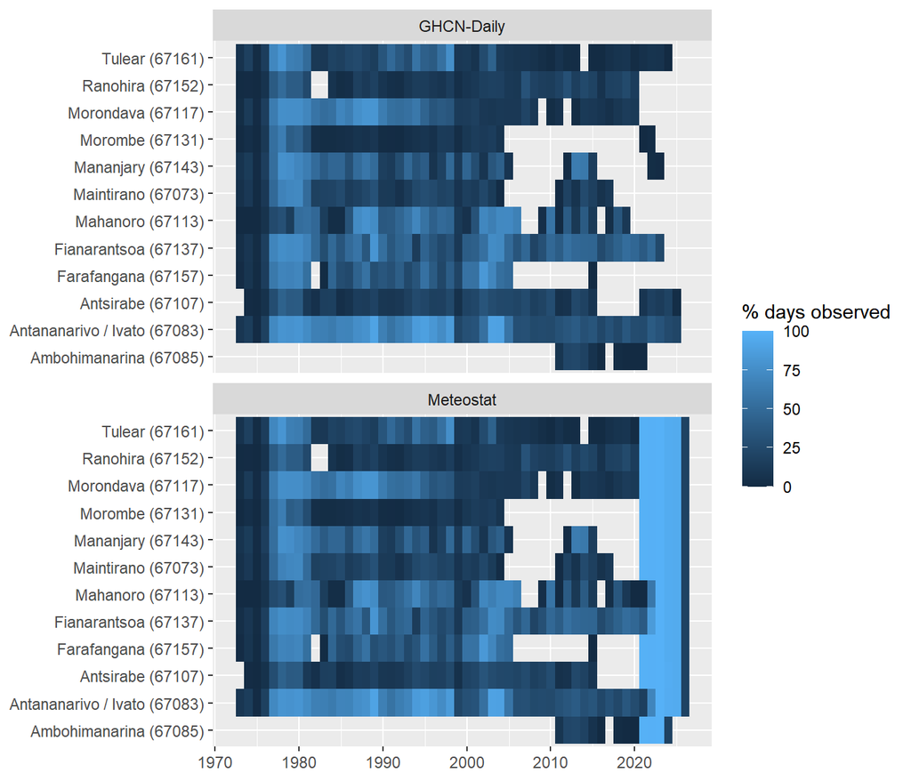

Figure 6: Share of days observed in each calendar year, by station and source.

```r
annual <- daily |>
  mutate(year = year(date)) |>
  group_by(source, name, wmo, year) |>
  summarise(
    n_obs = sum(!is.na(prcp)),
    total_mm = sum(prcp, na.rm = TRUE),
    .groups = "drop"
  ) |>
  mutate(
    days_in_year = if_else(leap_year(year), 366, 365),
    complete = n_obs >= 0.9 * days_in_year,
    total_complete = if_else(complete, total_mm, NA_real_)
  )

year_coverage <- annual |>
  mutate(pct_obs = 100 * n_obs / days_in_year)

year_coverage |>
  ggplot(aes(year, name, fill = pct_obs)) +
  geom_tile() +
  facet_wrap(~source, ncol = 1, scales = "free_y") +
  labs(x = NULL, y = NULL, fill = "% days observed")
```

```r
monthly <- daily |>
  mutate(year = year(date), month = month(date)) |>
  group_by(source, name, wmo, year, month) |>
  summarise(
    n_obs = sum(!is.na(prcp)),
    total_mm = sum(prcp, na.rm = TRUE),
    .groups = "drop"
  ) |>
  mutate(
    days = days_in_month(ymd(paste(year, month, 1))),
    complete = n_obs >= 0.8 * days,
    total_complete = if_else(complete, total_mm, NA_real_)
  )

clim_month <- monthly |>
  filter(year %in% clim_years) |>
  group_by(source, name, month) |>
  summarise(
    mean_mm = mean(total_complete, na.rm = TRUE),
    n_years = sum(complete),
    .groups = "drop"
  ) |>
  filter(n_years >= 5)
```

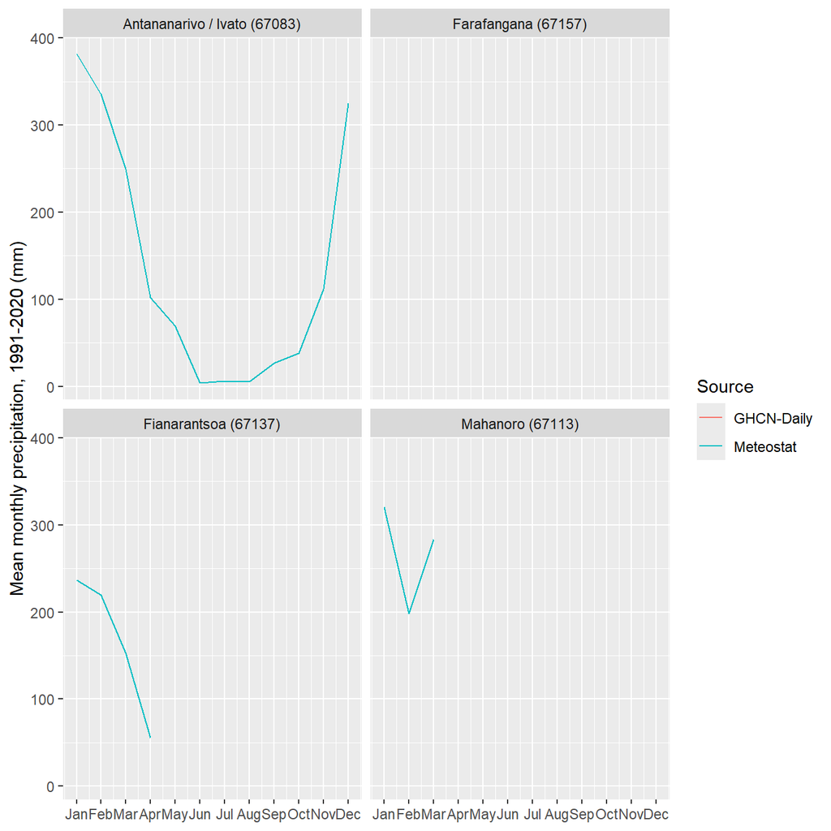

Figure 7: Mean monthly precipitation, 1991-2020, from months with at least 80% of days observed. A month is shown only if at least 5 years are complete for it, so the means rest on few years and are indicative only.

```r
clim_month |>
  ggplot(aes(month, mean_mm, color = source)) +
  geom_line() +
  facet_wrap(~name, ncol = 2) +
  scale_x_continuous(breaks = 1:12, labels = month.abb) +
  labs(x = NULL, y = "Mean monthly precipitation, 1991-2020 (mm)", color = "Source")
```